# Atividade 03

# 1 Introdução

Este trabalho utiliza o conjunto de dados education, do UK Office for National Statistics, que contém informações socioeconômicas e educacionais de cidades inglesas, incluindo níveis de qualificação, presença de universidades, renda e densidade de emprego.

O objetivo é desenvolver modelos preditivos para estimar o `education_score` de cada cidade, identificando também as variáveis mais influentes sobre o desempenho educacional.

As Seções 2 e 2.1 descrevem o conjunto de dados, sua origem e o processo de preparação inicial, incluindo limpeza e divisão em conjuntos de treino e teste. A Seção 3 apresenta a análise exploratória, destacando padrões e relações relevantes entre as variáveis preditoras e o desempenho educacional. Na Seção 4, diferentes algoritmos de regressão, Regressão Linear, Elastic Net, Boosting e Floresta Aleatória, são ajustados e comparados por meio de validação cruzada, permitindo avaliar a eficácia de cada abordagem.

# 2 Banco de dados

O conjunto de dados com 1104 observações e 31 variáveis foi disponibilizado pelo *UK Office for National Statistics* e uma discussão sobre o mesmo pode ser encontrada no artigo [“Why do children and young people in smaller towns do better academically than those in larger towns?”](https://www.ons.gov.uk/peoplepopulationandcommunity/educationandchildcare/articles/whydochildrenandyoungpeopleinsmallertownsdobetteracademicallythanthoseinlargertowns/2023-07-25). O *codebook* do conjunto de dados está disponível no link.

Cada observação se refere às características sociais e educacionais de cidades inglesas, utilizadas nesse trabalho com o intuito de atingir o objetivo de predizer o nível de escolaridade dessas cidades.

A Tabela abaixo resume a composição dos tipos de variáveis presentes no conjunto de dados.

Tabela 2.1: Tipos de Variáveis Presentes no Conjunto de Dados

| Variável | Tipo de Variável |
| --- | --- |
| town11cd | character |
| town11nm | character |
| population_2011 | numeric |
| size_flag | character |
| rgn11nm | character |
| coastal | character |
| coastal_detailed | character |
| ttwa11cd | character |
| ttwa11nm | character |
| ttwa_classification | character |
| job_density_flag | character |
| income_flag | character |
| university_flag | character |
| level4qual_residents35_64_2011 | character |
| ks4_2012_2013_counts | numeric |
| key_stage_2_attainment_school_year_2007_to_2008 | numeric |
| key_stage_4_attainment_school_year_2012_to_2013 | numeric |
| level_2_at_age_18 | numeric |
| level_3_at_age_18 | numeric |
| activity_at_age_19_full_time_higher_education | numeric |
| activity_at_age_19_sustained_further_education | numeric |
| activity_at_age_19_appprenticeships | numeric |
| activity_at_age_19_employment_with_earnings_above_0 | numeric |
| activity_at_age_19_employment_with_earnings_above_10_000 | numeric |
| activity_at_age_19_out_of_work | numeric |
| highest_level_qualification_achieved_by_age_22_less_than_level_1 | numeric |
| highest_level_qualification_achieved_by_age_22_level_1_to_level_2 | numeric |
| highest_level_qualification_achieved_by_age_22_level_3_to_level_5 | numeric |
| highest_level_qualification_achieved_by_age_22_level_6_or_above | numeric |
| highest_level_qualification_achieved_b_age_22_average_score | numeric |
| education_score | numeric |

## 2.1 Divisão dos dados em Treino e Teste

Para a preparação dos dados, o primeiro passo consistiu em uma rigorosa seleção de variáveis. Inicialmente, foram removidas colunas de identificação textual (`town11cd`, `town11nm`, etc.), que não possuem valor preditivo.

O passo mais crítico foi evitar o **vazamento de informações** (*data leakage*), que ocorre quando o modelo tem acesso a dados que não estariam disponíveis em um cenário real de previsão. A variável alvo, `education_score`, é um indicador composto, criado a partir de outras variáveis presentes no dataset. Conforme detalhado no artigo, as métricas `key_stage_2_attainment_school_year_2007_to_2008`, `key_stage_4_attainment_school_year_2012_to_2013`, `level_3_at_age_18` e `highest_level_qualification_achieved_by_age_22_level_6_or_above` foram usadas diretamente em sua construção e, por isso, não usadas nos modelos.

Seguindo essa mesma lógica, foram removidas também outras variáveis que, embora não sejam componentes diretos, medem a proporção da cidade que atingiu um determinado nível de qualificação até uma determinada idade, ou seja, o mesmo conceito em níveis mais baixos. Assim, as variáveis `level_2_at_age_18`, `highest_level_qualification_achieved_by_age_22_less_than_level_1`, `highest_level_qualification_achieved_by_age_22_level_1_to_level_2` e `highest_level_qualification_achieved_by_age_22_level_3_to_level_5` foram removidas. Além disso, a variável `highest_level_qualification_achieved_b_age_22_average_score` também foi removida pois exibe a pontuação média mais alta de qualificação das cidades com base nos maiores níveis de qualificação educacional até 22 anos.

Manter essas variáveis tornaria o problema de predição fácil, pois estaria essencialmente usando uma versão da resposta para prever a própria resposta. O objetivo é prever o desempenho educacional a partir de fatores socioeconômicos e demográficos, e não a partir de outras métricas de desempenho educacional.

Após essa filtragem, o conjunto de dados foi dividido em **80% para treinamento** e **20% para teste**, utilizando uma semente (`set.seed(123)`) para garantir a reprodutibilidade dos resultados. O conjunto de treinamento contém 883 observações, que serão usadas para construir os modelos, enquanto o conjunto de teste, com 221 observações, será mantido separado para a avaliação final. Essa separação é crucial para uma avaliação honesta da capacidade de generalização do modelo em dados novos.

Além disso, foi utilizada validação cruzada do tipo k-fold, com 5 partições. Esse método divide o conjunto de treinamento em cinco partes: o modelo é ajustado cinco vezes, utilizando quatro partes para treino e uma para validação a cada iteração. Dessa forma, obtém-se uma estimativa mais estável do desempenho médio, reduzindo a variabilidade e o risco de overfitting.

# 3 Análise exploratória

A princípio, foi analisada a distribuição da variável resposta `education_score`, que representa o desempenho educacional médio nas localidades do Reino Unido. A Figura 3.1 mostrou uma distribuição aproximadamente simétrica, com concentração em zero, o valor padronizado como a média nacional.

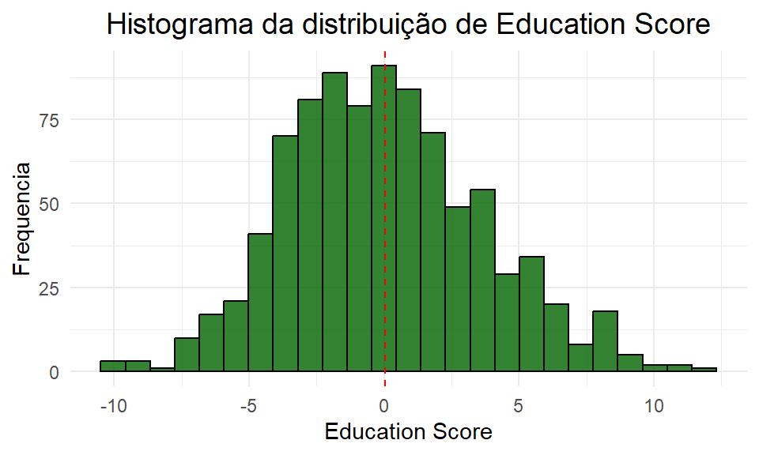

Figura 3.1: Histograma da distribuição de Education Score

Tabela 3.1: Correlações das Variáveis Numéricas com a Variável Resposta

| Variável | Correlação com Education Score |
| --- | --- |
| education_score | 1.0000000 |
| activity_at_age_19_full_time_higher_education | 0.8784247 |
| activity_at_age_19_out_of_work | -0.5690987 |
| activity_at_age_19_sustained_further_education | -0.3241654 |
| activity_at_age_19_employment_with_earnings_above_10_000 | -0.2794319 |
| population_2011 | -0.1180429 |
| activity_at_age_19_appprenticeships | -0.1138876 |
| activity_at_age_19_employment_with_earnings_above_0 | -0.1110539 |
| ks4_2012_2013_counts | -0.0116668 |

A Tabela 3.1 revela a associação linear entre as variáveis numéricas e o `education_score`. A correlação positiva mais forte (**0.878**) é com `activity_at_age_19_full_time_higher_education`, indicando que uma maior proporção de jovens no ensino superior está fortemente associada a um melhor desempenho educacional na localidade.

Por outro lado, a correlação negativa mais expressiva (**-0.569**) ocorre com a variável `activity_at_age_19_out_of_work`, sugerindo que o desemprego ou a inatividade entre os jovens de 19 anos é um forte indicador de um menor `education_score`. Outras atividades, como a entrada precoce no mercado de trabalho (`activity_at_age_19_employment_with_earnings_above_10_000`), também apresentam correlações negativas moderadas.

Finalmente, variáveis como `population_2011` e `ks4_2012_2013_counts` mostram correlações próximas de zero, sugerindo ausência de uma relação linear significativa com a variável resposta.

Tabela 3.2: Correlacoes fortes entre variaveis preditoras (|r| > 0.7)

| Variavel 1 | Variavel 2 | Correlacao |
| --- | --- | --- |
| population_2011 | ks4_2012_2013_counts | 0.991 |
| activity_at_age_19_sustained_further_education | activity_at_age_19_appprenticeships | 0.864 |
| activity_at_age_19_employment_with_earnings_above_0 | activity_at_age_19_employment_with_earnings_above_10_000 | 0.785 |

Após analisar a relação dos preditores com a variável resposta, investigou-se a multicolinearidade entre os próprios preditores.

A Tabela 3.2 mostra os pares de variáveis com correlação de Pearson superior a 0,7. Para reduzir esse efeito, foi removida uma variável de cada par, considerando dois critérios: relevância conceitual e correlação individual com o `education_score`.

Por exemplo, `ks4_2012_2013_counts` foi descartada em favor de `population_2011`, por ser conceitualmente redundante. Variáveis como `activity_at_age_19_appprenticeships` e `activity_at_age_19_employment_with_earnings_above_0` também foram removidas por apresentarem correlação mais baixa com a variável resposta.

Desse modo, a exclusão dessas variáveis buscou manter no conjunto de dados apenas aquelas que fornecem informações distintas e relevantes para a modelagem, reduzindo o risco de multicolinearidade e aumentando a robustez do modelo final.

A Figura 3.2 exibe boxplots de `education_score` pelo tamanho das cidades. A partir dessa figura foi possível observar que o tamanho das cidades tem grande influência principalmente na disperção dos dados, com grandes cidades apresentando baixa disperção (apesar de scores majoritariamente negativos) e pequenos municípios apresentando grande disperção. Assim, quanto menor a cidade, maior é a disperção de `education_score`.

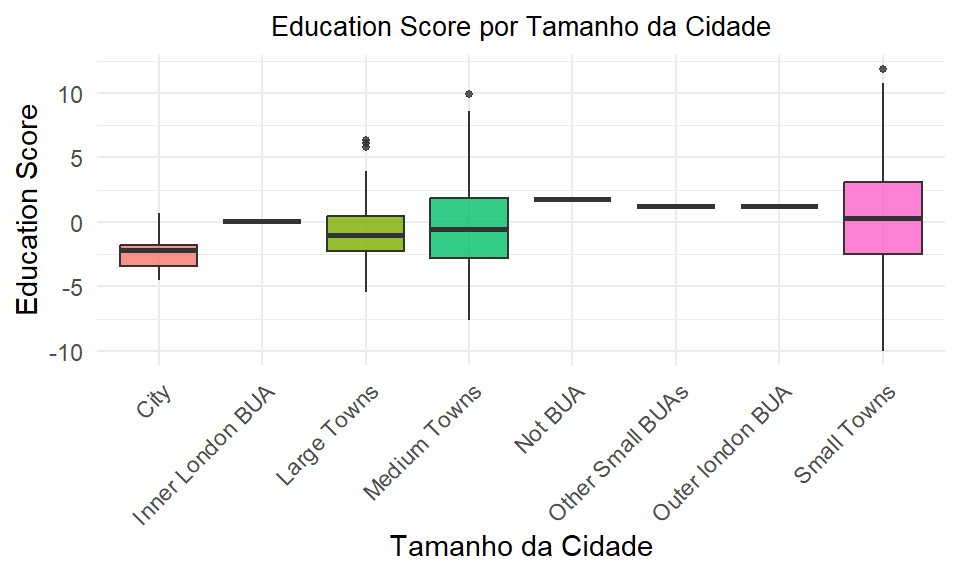

Figura 3.2: Education Score por Tamanho da Cidade

A Figura 3.3 apresenta o education score por região que, apesar de não aparentarem possuir grandes diferenças entre si, quando incluídas nos modelos são significativas.

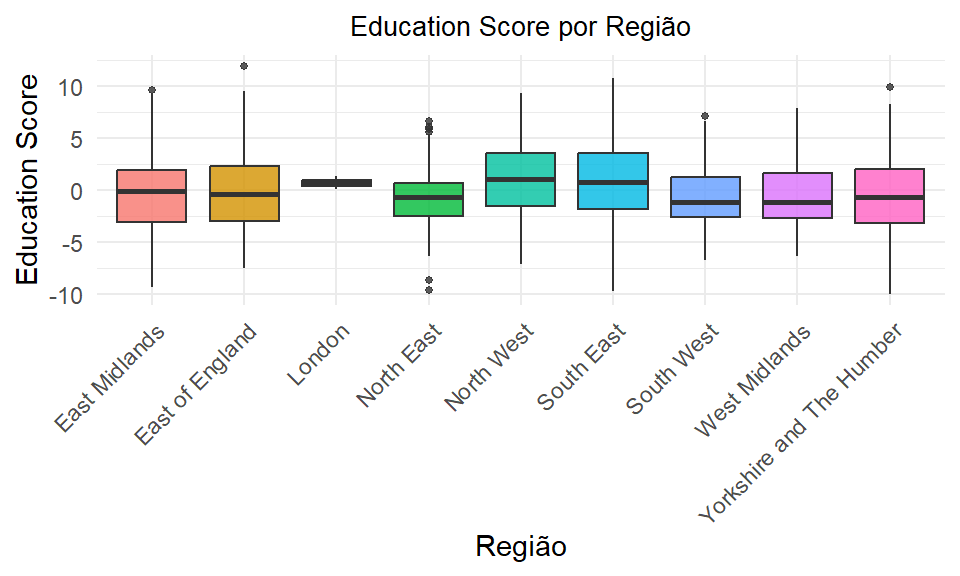

Figura 3.3: Education Score por Região

A partir da Figura 3.4, é possível concluir que áreas costeiras têm, em média, Ecucation Scores mais baixos se comparadas com áreas não costeiras.

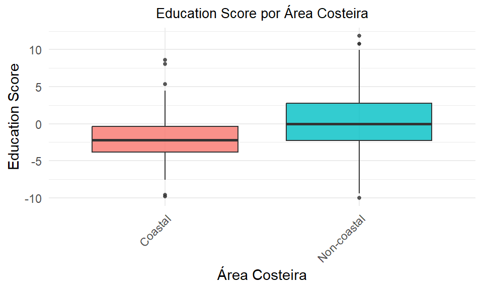

Figura 3.4: Education Score por Área Costeira

Ao observar áreas costeiras mais detalhadamente, não é possível concluir que há grandes diferenças entre os tipos de áreas costeiras, como demosntrado na Figura 3.5.

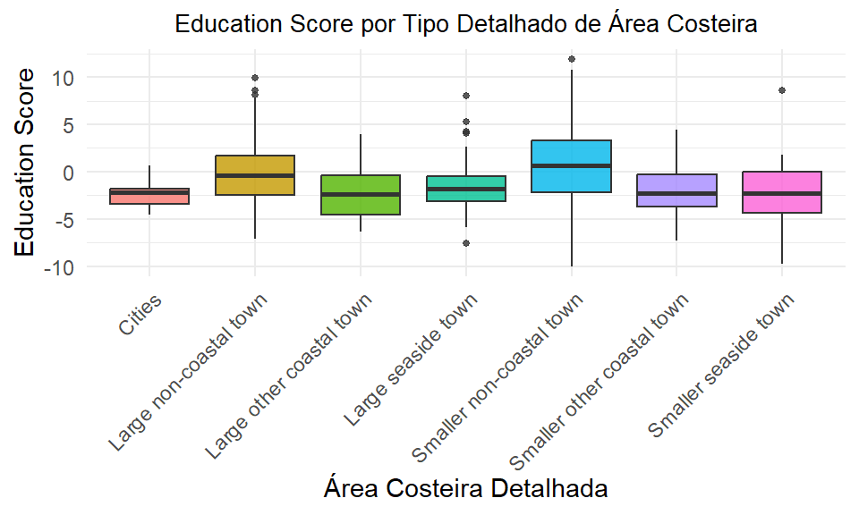

Figura 3.5: Education Score por Tipo Detalhado de Área Costeira

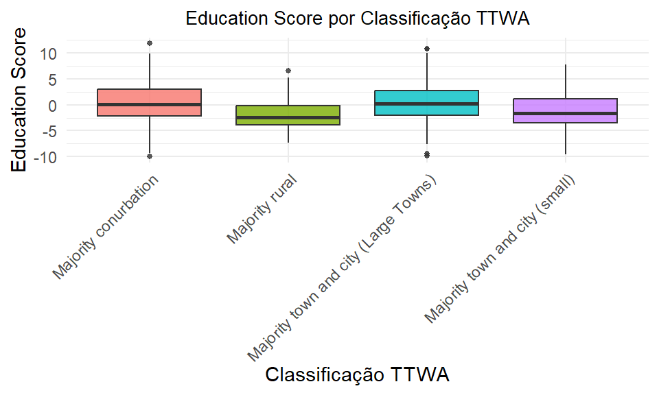

Figura 3.6: Education Score por Classificação TTWA

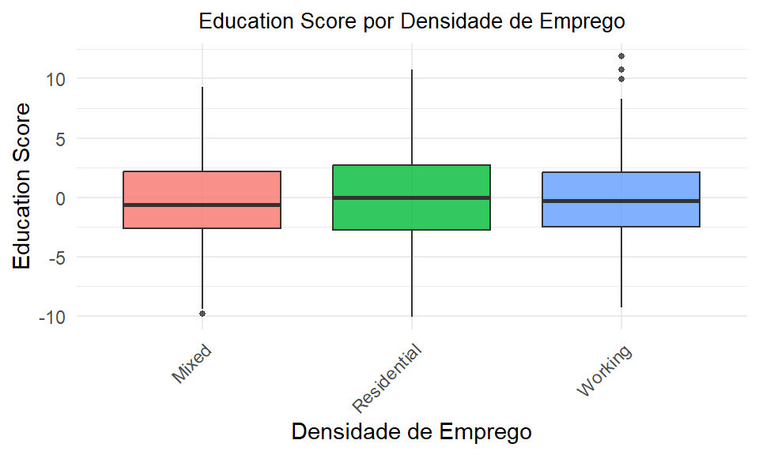

Figura 3.7: Education Score por Densidade de Emprego

A faixa de renda, entretanto, é claramente um fator que corrobora para o bom desempenho dos alunos. Na Figura 3.8, ao deixarmos de olhar para $cities$ e observarmos apenas $towns$, é evidente que quanto maior a deprivação salarial dos municípios, menor é seu Education Score. $Cities$ por sua vez, tem comportamento semelhante à cidades com maior deprivação salarial.

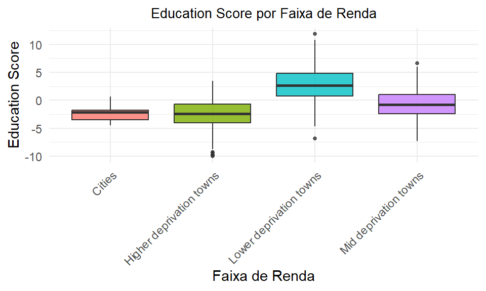

Figura 3.8: Education Score por Faixa de Renda

A partir da Figura 3.9 é possível observar que a presença de universidade na cidade/município não afeta o Education Score de forma muito evidente. A dispersão dos scores obtidos é nitidamente menor mas vale ressaltar que no conjunto de dados selecionado para o treino dos modelos, apenas 52 das 883 cidades constam com a presença de universidades.

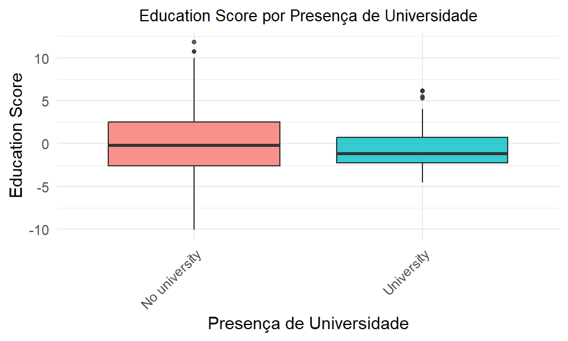

Figura 3.9: Education Score por Presença de Universidade

Em questão influência do nível de qualificação dos residentes de 35 a 64 anos no score dos alunos, a Figura 3.10 deixa evidente que quanto mais qualificados os residentes de uma cidade/município são, melhor é o seu desempenho educacional.

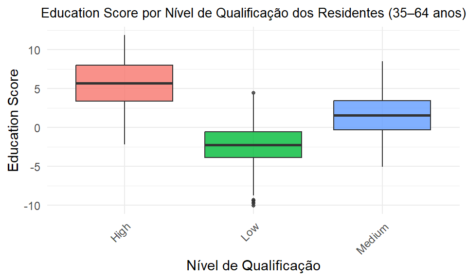

Figura 3.10: Education Score por Nível de Qualificação dos Residentes (35–64 anos)

Tabela 3.3: Matriz de Cramer para as variáveis categóricas

|  | size_flag | rgn11nm | coastal | coastal_detailed | ttwa_classification | job_density_flag | income_flag | university_flag | level4qual_residents35_64_2011 |
| --- | --- | --- | --- | --- | --- | --- | --- | --- | --- |
| size_flag | 1 | NaN | NaN | NaN | NaN | NaN | NaN | NaN | NaN |
| rgn11nm | NaN | 1 | NaN | NaN | NaN | NaN | NaN | NaN | NaN |
| coastal | NaN | NaN | 1.0000000 | 0.9827206 | 0.2458254 | 0.1071247 | 0.2825736 | 0.0427084 | 0.1008097 |
| coastal_detailed | NaN | NaN | 0.9827206 | 1.0000000 | 0.2058714 | 0.2905568 | 0.6145682 | 0.5450844 | 0.1426877 |
| ttwa_classification | NaN | NaN | 0.2458254 | 0.2058714 | 1.0000000 | 0.1253272 | 0.1685724 | 0.1190714 | 0.1513148 |
| job_density_flag | NaN | NaN | 0.1071247 | 0.2905568 | 0.1253272 | 1.0000000 | 0.1116385 | 0.2566439 | 0.0521364 |
| income_flag | NaN | NaN | 0.2825736 | 0.6145682 | 0.1685724 | 0.1116385 | 1.0000000 | 0.5098482 | 0.5166073 |
| university_flag | NaN | NaN | 0.0427084 | 0.5450844 | 0.1190714 | 0.2566439 | 0.5098482 | 1.0000000 | 0.0673464 |
| level4qual_residents35_64_2011 | NaN | NaN | 0.1008097 | 0.1426877 | 0.1513148 | 0.0521364 | 0.5166073 | 0.0673464 | 1.0000000 |

Para analisar a associação entre as variáveis preditoras categóricas, foi utilizada a estatística V de Cramer, cujos resultados estão na Tabela 3.3. O V de Cramer mede a força da associação entre duas variáveis nominais, variando de 0 (sem associação) a 1 (associação perfeita). A análise revelou uma associação quase perfeita de **0.983** entre `coastal` e `coastal_detailed`, indicando alta redundância, que a segunda é apenas uma versão mais detalhada da primeira. Para evitar multicolinearidade, a variável `coastal_detailed` foi removida, preservando a informação essencial através da variável binária `coastal`.

Tabela 3.4: Contagem de valores ausentes no conjunto de treino

| Variável | Valores Ausentes |
| --- | --- |
| population_2011 | 4 |
| size_flag | 0 |
| rgn11nm | 2 |
| coastal | 4 |
| ttwa_classification | 4 |
| job_density_flag | 4 |
| income_flag | 4 |
| university_flag | 4 |
| level4qual_residents35_64_2011 | 4 |
| activity_at_age_19_full_time_higher_education | 1 |
| activity_at_age_19_sustained_further_education | 43 |
| activity_at_age_19_employment_with_earnings_above_10_000 | 22 |
| activity_at_age_19_out_of_work | 377 |
| education_score | 0 |

A etapa final do pré-processamento lidou com os dados ausentes. Foi observado que a coluna `activity_at_age_19_out_of_work` continha um volume massivo de valores faltantes (377 no conjunto de treino). Tentar preencher uma lacuna de informação tão grande poderia distorcer os padrões reais dos dados e levar a um modelo enviesado. Para garantir a integridade da análise e a robustez dos resultados, optou-se pela remoção completa desta variável.

A estrutura final dos dados que serão utilizados para treinar os algoritmos é apresentada a seguir.

Tabela 3.5: Estrutura Final dos Dados

| Variável | Tipo de Variável |
| --- | --- |
| population_2011 | numeric |
| size_flag | factor |
| rgn11nm | factor |
| coastal | factor |
| ttwa_classification | factor |
| job_density_flag | factor |
| income_flag | factor |
| university_flag | factor |
| level4qual_residents35_64_2011 | factor |
| activity_at_age_19_full_time_higher_education | numeric |
| activity_at_age_19_sustained_further_education | numeric |
| activity_at_age_19_employment_with_earnings_above_10_000 | numeric |
| education_score | numeric |

# 4 Modelos propostos

Os modelos propostos nesse trabalho para predizer o nível de escolaridade das cidades inglesas são: Regressão Linear Múltipla, Regressão Linear Regularizada com Elastic Net (união dos métodos de regularização Ridge e Lasso), Florestas Aleatórias e Boosting. Esses algoritmos se baseiam em técnicas de aprendizado de máquina supervisionado para problemas de regressão, ou seja, que fazem predição de valores numéricos contínuos.

## 4.1 Regressão Linear Múltipla (LM)

A função de predição da Regressão Linear considera que a variável resposta possa ser explicada como uma combinação linear das variáveis explicativas ponderadas por um conjunto de parâmetros $\boldsymbol{\beta} = (\beta_0, \ldots, \beta_d)$, e pode ser representada pela seguinte forma apresentada por (Izbicki and Santos 2020):

$$g(\mathbf{x}) \;=\; \boldsymbol{\beta}^\top \mathbf{x}
\;=\; \sum_{i=0}^{d} \beta_i\,x_i$$

Os parâmetros são estimados pelo método dos mínimos quadrados, que minimiza a distância entre os pontos e o hiperplano formado pela combinação linear. Ademais, o pré processamento desse algoritmo de predição contou com a centralização e padronização das variáveis, para que apresentassem média zero e desvio padrão igual a um.

## 4.2 Regressão Linear Regularizada com Elastic Net (GLMnet)

A Regressão linear regularizada com Elastic Net foi proposta em 2005 por (Zou and Hastie 2005) como um novo método de regularização e seleção de variáveis. O método Elastic Net foi desenvolvido para superar as limitações de duas técnicas de regularização: Regressão Ridge (penalidade $L_2$) e Lasso (penalidade $L_1$).

Embora a Regressão Ridge melhore a predição por meio de um `encolhimento (shrinkage)` contínuo dos coeficientes, não é capaz de produzir um modelo parcimonioso, pois sempre mantém todos os preditores. Já em relação a Regressão Lasso, ela realiza o encolhimento e a seleção de variáveis simultaneamente, porém apresenta limitações na existência de variáveis altamente correlacionadas, por só selecionar uma delas, e também quando o número de preditores ($p$) é muito maior do que o número de observações ($n$), pois só seleciona no máximo $n$ variáveis.

O Elastic Net combina as penalidades do Lasso ($L_1$) e do Ridge ($L_2$), buscando encontrar os coeficientes $(\beta_0, \beta)$ que minimizam a seguinte expressão utilizada no pacote `glmnet`(Friedman, Hastie, & Tibshirani, 2010):

$$\min_{(\beta_{0},\beta)} \left[ \frac{1}{2N}\sum_{i=1}^{N}(y_{i}-\beta_{0}-x_{i}^{\top}\beta)^{2}+\lambda P_{\alpha}(\beta) \right]$$

Onde $P_{\alpha}(\beta)$ é a penalidade Elastic Net:

$$P_{\alpha}(\beta) = (1-\alpha)\frac{1}{2}||\beta||_{l_{2}}^{2}+\alpha||\beta||_{l_{1}}$$
E os componentes da norma são:

- $||\beta||_{l_{1}} = \sum_{j=1}^{p}|\beta_{j}|$ (A penalidade $L_1$ do Lasso)
- $||\beta||_{l_{2}}^{2} = \sum_{j=1}^{p}\beta_{j}^{2}$ (A penalidade $L_2$ do Ridge)

O hiperparâmetro $\alpha$ controla a mistura entre os dois. Se $\alpha=1$, o modelo é o Lasso puro, mas se $\alpha=0$, o modelo é a Ridge pura. Para $0 < \alpha < 1$, o modelo é uma mistura que remove as instabilidades do Lasso, mas mantém sua capacidade de seleção de variáveis.

Dessa forma, o Elastic Net realiza a seleção automática de variáveis, consegue incluir ou excluir grupos de preditores fortemente correlacionados, não seleciona apenas $n$ variáveis.

Neste trabalho, o processo de validação cruzada selecionou os melhores valores de $\alpha$ e $\lambda$, sendo: 0.55 (modelo Elastic Net) e 0.0606772, respectivamente. As variáveis preditoras também foram centralizadas e padronizadas.

## 4.3 Florestas aleatórias (RF)

Florestas aleatórias (Random Forests) são um método que melhora a técnica de Bagging, que é um procedimento baseado em reduzir a alta variância das árvores de decisão. Essa técnica cria amostras bootstrap (com resposição) do conjunto de treino, ajusta árvores de decisão profundas para cada amostra, e utiliza a média das predições para fazer uma predição final. Porém, se houver um forte preditor no conjunto de dados, a maioria das árvores irá utilizar essa variável na primeira divisão, fazendo com que se tornem parecidas e, consequentemente, alto correlacionadas (James et al. 2013).

Assim, na construção de árvores na Floresta aleatória, a cada divisão (nó), o algortimo seleciona aleatoriamente um conjunto de $m$ preditores do conjunto total de $p$ preditores. Se $m=p$, a Floresta aleatória é igual ao Bagging. Este método torna as árvores menos correlacionadas, o que resulta em uma redução maior da variância, tornando a média das previsões mais confiável.

Neste trabalho, o número de árvores utilizadas foi igual a $500$ e, pela validação cruzada, o subconjunto que gerou o menor erro médio foi de $m=14$ (considerando que $p \geq 26$, juntando variáveis numéricas e dummies automaticamente criadas).

## 4.4 Boosting

O método Boosting também é uma técnica de `ensemble`, que combina estimadores fracos, como árvores de decisão. Entretanto, ao invés de criar as árvores de forma independente, como no Bagging, elas são combinadas de forma sequencial e adaptativa. O procedimento é iterativo, assim cada nova árvore é construída utilizando informações das árvores já ajustadas, com o objetivo de corrigir os erros cometidos pelos modelos anteriores.

Como exposto por (James et al. 2013), o modelo inicial ($\hat{f}(x)$) começa nulo, e os resíduos ($r_i$) são iguais aos valores da variável resposta ($y_i$). Em cada iteração, é ajustada uma árvore utilizando os resíduos atuais como a variável dependente. O modelo atual é atualizado com uma versão `encolhida (shrunken)` da nova ávore, controlada pela taxa de aprendizado ($\lambda$):

$$\hat{f}(x) \leftarrow \hat{f}(x) + \lambda \hat{f}^b(x)$$
Após isso, os resíduos são atualizados para a próxima iteração, refletindo os erros que o novo modelo ainda comete:

$$r_i \leftarrow r_i - \lambda \hat{f}^b(x_i)$$
O modelo final é a soma ponderada pela taxa de aprendizado de todas as árvores construídas sequencialmente:

$$\hat{f}(x) = \sum_{b=1}^{B} \lambda \hat{f}^b(x)$$
Como nesse modelo um alto número de árvores pode levar ao sobreajuste, o melhor modelo escolhido pela validação cruzada utilizou 1500 iterações. Além disso, foram definidos os parâmetros $p=2$ de profundidade das árvores e $\lambda=0.01$, conforme sugerido por Izbicki e Santos.

## 4.5 Comparação entre os modelos

Tabela 4.1: Resumo das métricas de desempenho dos modelos propostos

| Modelo | RMSE_CV | Rsquared_CV | MAE_CV |
| --- | --- | --- | --- |
| GLMnet | 1.535402 | 0.8069919 | 1.181137 |
| LM | 1.550685 | 0.8030588 | 1.184712 |
| BOOSTING | 1.567402 | 0.7989465 | 1.209799 |
| RF | 1.606319 | 0.7884654 | 1.243258 |

Com base nos resultados expostos na Tabela 4.1, o modelo de Regressão Linear Regularizada com Elastic Net demonstrou o melhor desempenho preditivo em todas as métricas utilizadas.Os menores valores da Raiz do Erro Quadrático Médio (RMSE) e do Erro Médio Absoluto (MAE) mostraram que entre os modelos propostos, o `GLMnet` apresenta, em média, os valores preditos mais próximos dos valores reais, utilizando os dados da validação cruzada.

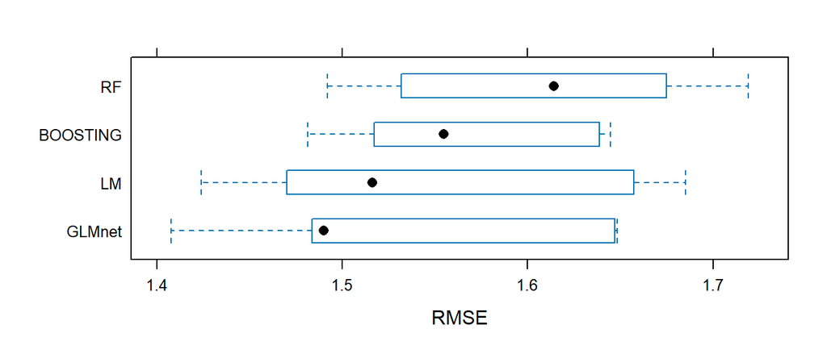

Figura 4.1: Comparação do RMSE entre os modelos propostos (Validação Cruzada)

A Figura 4.1 mostra que os modelos considerados mais simples e interpretáveis (`GLMnet` e `LM`) apresentam as menores medianas e valores mínimos, com uma maior concentração dos dados à esquerda, indicando menores valores de RMSE. Ademais, também foi possível notar nesses modelos uma variabilidade dos dados um pouco maior em relação aos outros, como o `Boosting`, que apresenta resultados mais estáveis.

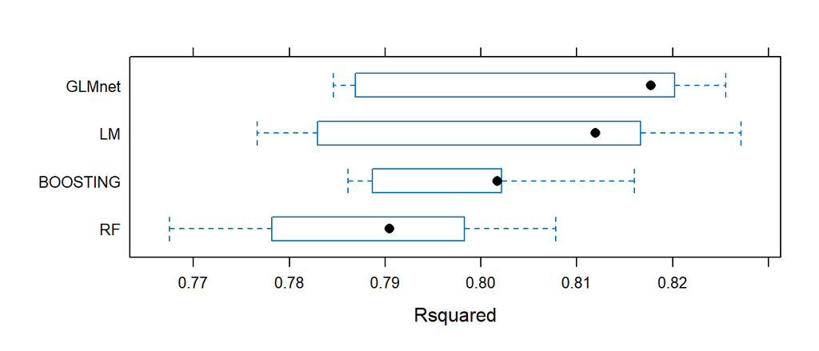

Figura 4.2: Comparação do R-squared entre os modelos propostos (Validação Cruzada)

É possível notar um desempenho semelhante na Figura 4.2, com os modelos `GLMnet` e `LM` apresentando as maiores medianas e valores máximos do $R^2$, indicando maiores proporções da variável resposta explicadas por esses modelos, apesar de uma variabilidade maior nos resultados.

# 5 Modelo Final

Os coeficientes estimados do melhor modelo (`GLMnet`) utilizando os dados de trainamento encontram-se na Tabela 5.1. Todas as variáveis com coeficientes zerados (sobre o tamanho da cidade, se é costeira ou não, etc.) foram excluídas do modelo pela componente Lasso, e consideradas redundantes ou irrelevantes para a predição do `education_score`. Já em relação às outras, os coeficientes indicam relações positivas ou negativas com a variável resposta.

Por exemplo, um aumento de um desvio padrão na variável `activity_at_age_19_full_time_higher_education`, relacionada à proporção de jovens de 19 anos em educação superior em tempo integral, está associado a um aumento de aproximadamente 2,7 unidades no `education_score`, mantendo todas as outras variáveis constantes.

Em relação a variável com fator negativo mais forte (`level4qual_residents35_64_2011$Low`), cidades na categoria de baixa proporção de adultos (35 a 64 anos) com qualificação de nível 4 ou superior, apresentam menos 0,22 unidades na pontuação educacional dos jovens em relação a cidades com alta proporção de adultos qualificados, mantendo todas as outras variáveis constantes.

Tabela 5.1: Coeficientes estimados pelo Modelo GLMnet em ordem de importância (valor absoluto)

| Variavel | Coeficiente |
| --- | --- |
| activity_at_age_19_full_time_higher_education | 2.6819 |
| income_flagLower deprivation towns | 0.3680 |
| rgn11nmNorth West | 0.2647 |
| activity_at_age_19_employment_with_earnings_above_10_000 | 0.2324 |
| level4qual_residents35_64_2011Low | -0.2225 |
| income_flagHigher deprivation towns | -0.2120 |
| activity_at_age_19_sustained_further_education | 0.1656 |
| population_2011 | -0.1572 |
| (Intercept) | -0.1471 |
| rgn11nmNorth East | 0.1328 |
| ttwa_classificationMajority town and city (small) | -0.1320 |
| ttwa_classificationMajority rural | -0.0900 |
| job_density_flagWorking | -0.0843 |
| rgn11nmEast of England | -0.0553 |
| university_flagUniversity | -0.0535 |
| ttwa_classificationMajority town and city (Large Towns) | -0.0300 |
| rgn11nmWest Midlands | -0.0124 |
| rgn11nmSouth East | -0.0062 |
| rgn11nmSouth West | 0.0047 |
| size_flagLarge Towns | 0.0000 |
| size_flagMedium Towns | 0.0000 |
| size_flagSmall Towns | 0.0000 |
| rgn11nmYorkshire and The Humber | 0.0000 |
| coastalNon-coastal | 0.0000 |
| job_density_flagResidential | 0.0000 |
| income_flagMid deprivation towns | 0.0000 |
| level4qual_residents35_64_2011Medium | 0.0000 |

Para avaliar o desempenho preditivo do modelo `GLMnet` e a capacidade de generalização, sua performance foi avaliada nos conjuntos de treinamento e teste. Dessa forma, foi possível observar na Tabela 5.2, que o modelo apresenta ótimos resultados, e o melhor desempenho encontra-se no conjunto teste, que apresenta dados não utilizados na otimização, com RMSE e MAE ligeiramente menores, e $R^2$ maior.

Tabela 5.2: Comparativo de Desempenho: Treino vs. Teste

| Conjunto | RMSE | Rsquared | MAE |
| --- | --- | --- | --- |
| Treino | 1.4973 | 0.8161 | 1.1510 |
| Teste | 1.4037 | 0.8308 | 1.0891 |

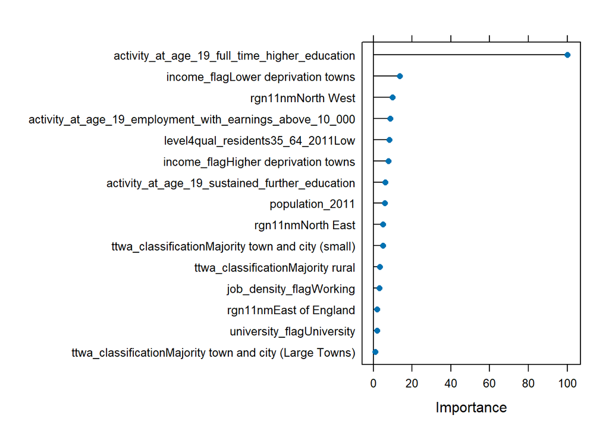

Figura 5.1: Importância das variáveis no modelo GLMnet

O gráfico de importância das variáveis mostra a contribuição de cada preditor para o education_score no modelo GLMnet. A variável `activity_at_age_19_full_time_higher_education` se destaca como a mais influente, atingindo a pontuação máxima de 100, indicando que a proporção de jovens de 19 anos matriculados em ensino superior em tempo integral é o principal determinante do desempenho educacional de uma cidade.

Em seguida, fatores socioeconômicos, representados por `income_flag`, exercem grande influência: cidades com menor privação de renda (“lower deprivation”) tendem a apresentar scores educacionais mais altos. A localização geográfica, especialmente a região Noroeste (`rgn11nm` = North West), aparece como o terceiro fator mais relevante, sugerindo disparidades regionais nos resultados.

Outras variáveis, como a proporção de jovens de 19 anos empregados com rendimento maior que 10000 (`activity_at_age_19_employment_with_earnings_above_10_000`) e a proporção de residentes com 35-64 anos que possuem qualificação de Nível 4 ou superior (`level4qual_residents35_64_2011Low`), contribuem de forma menor, mas ainda relevante, para o modelo.

Em resumo, o desempenho educacional é majoritariamente guiado pela taxa de participação no ensino superior, seguido por condições econômicas locais e fatores regionais.

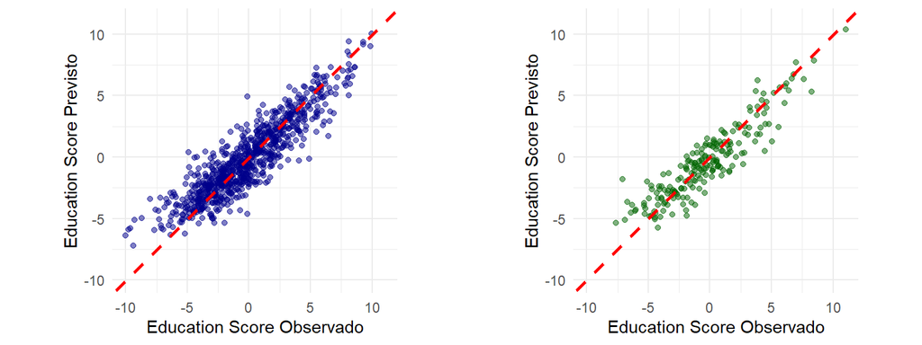

Figura 5.2: Desempenho do modelo GLMnet no Conjunto de Treino e Teste

O gráfico à esquerda (pontos em azul) mostra o desempenho do modelo nos dados de treinamento. Os pontos estão bem próximos da linha, o que indica que o modelo conseguiu aprender bem os padrões desses dados. Já o gráfico à direita (pontos em verde), que representa o conjunto de teste, apresenta um resultado muito parecido, mostrando que o modelo consegue fazer boas previsões em dados novos, que não foram usados no treino. Essa consistência entre os dois conjuntos sugere que o modelo não sofre de sobreajuste (overfitting), ou seja, não se limitou a memorizar os exemplos de treino, mas aprendeu relações reais e replicáveis. Além disso, os pontos estão distribuídos de forma equilibrada ao redor da linha, o que mostra que o modelo não tem tendência a superestimar nem subestimar os valores do `education_score`.

# 6 Discussão

Os resultados mostraram que os modelos de regressão linear e GLMnet foram os que melhor explicaram o education_score, o que indica que as relações entre as variáveis do estudo são basicamente lineares. Ou seja, quando uma variável aumenta ou diminui, o education_score tende a mudar de forma proporcional, sem precisar de modelos mais complexos para representar essas relações.

O GLMnet teve um bom desempenho pois consegue lidar bem com variáveis que estão muito correlacionadas entre si, selecionando apenas as mais importantes para o modelo, o fato de ele e o modelo linear simples apresentarem resultados parecidos mostra que o comportamento dos dados é relativamente estável e previsível. Além disso, o melhor desempenho do GLMnet em relação a métodos mais complexos, como Boosting e Random Forest, sugere que a complexidade adicional desses algoritmos não se traduz em ganhos significativos para este conjunto de dados.

No contexto do problema, o modelo é muito útil para entender quais fatores mais influenciam o desempenho educacional nas cidades do Reino Unido. As variáveis que mais se destacaram foram aquelas ligadas à continuidade dos estudos após o ensino médio, como a proporção de jovens de 19 anos no ensino superior, além de fatores socioeconômicos, como renda e emprego.

De forma geral, o modelo ajuda a mostrar que o desempenho educacional não depende só da escola em si, mas também das condições sociais e econômicas de cada região. Assim, ele pode servir de apoio para a criação de políticas públicas que busquem melhorar o acesso à educação e reduzir desigualdades regionais.

# 7 Bibliografia

Izbicki, Rafael, and Tiago Mendonça dos Santos. 2020. *Aprendizado de máquina: Uma Abordagem Estatı́stica*. São Carlos, SP: Rafael Izbicki.

James, Gareth, Daniela Witten, Trevor Hastie, and Robert Tibshirani. 2013. *An Introduction to Statistical Learning: With Applications in r*. New York: Springer.

Zou, Hui, and Trevor Hastie. 2005. “Regularization and Variable Selection via the Elastic Net.” *Journal of the Royal Statistical Society: Series B (Statistical Methodology)* 67 (2): 301–20.